# Red Wine Quality by Fares Badr

##### Let’s check pH vs citric and fixed acids:

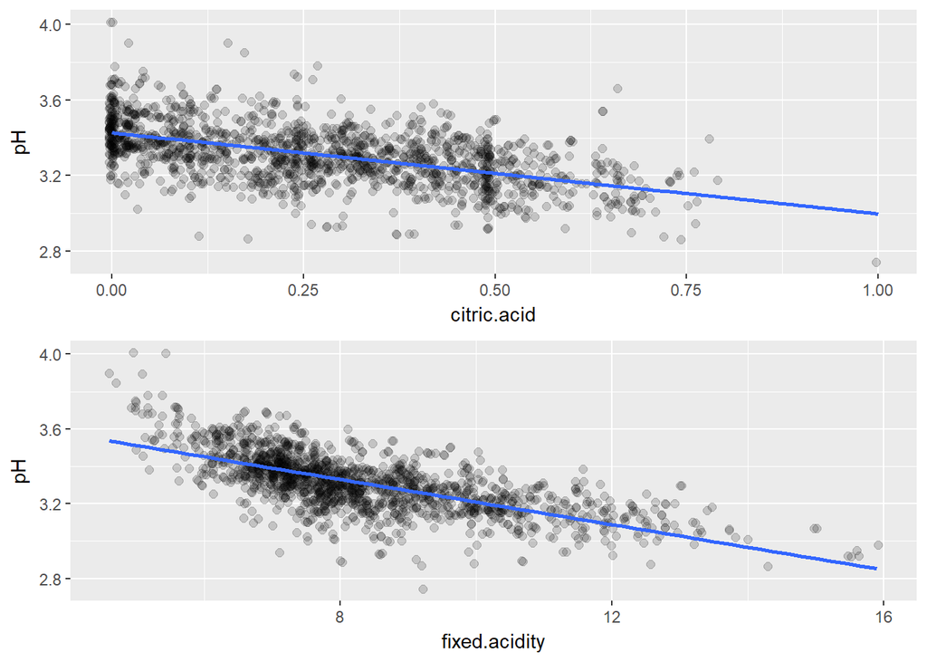

There is negative relationship between (pH and Fixed acidity) and (pH and citric acid) this is obvious since the lower pH level is equivalent to a higher acid strength.

The negative relationship is bit stronger with fixed acidity due to its higher concentration compared to citric acid found in the red wine samples.

##### Let’s check pH vs sulphates:

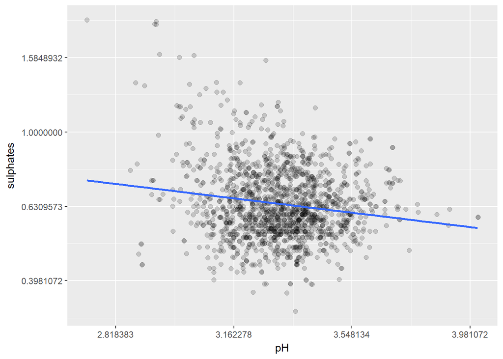

log transform x-axis and y-axis, We notice a weak negative relationship between pH and sulphates. Nothing important in this plotother than most of the observations are stacked between 0.53 and 0.63 g/dm^3 for pH level between 3.2 and 3.3 g/dm^3.

# Bivariate Analysis

### Talk about some of the relationships you observed in this part of the investigation. How did the feature(s) of interest vary with other features in the dataset?

Wine quality has a moderate correlations with:

- Alcohol percentage
- Volatile acidity

And a weaker relationship with:

- citric acid
- sulphates

It appears that the alcohol level has an impact on the wine quality Higher quality wines tend to have lower volatile acid levels.

It seems there is a negative relationship between alcohol percentage and density. When the alcohol percentage increases it looks like the density decreases.

### Did you observe any interesting relationships between the other features (not the main feature(s) of interest)?

Sulphates and chlorides seems to be correlated between each others. And we have a strong positive correlation between total SO2 and Free SO2

We noticed a relationship between pH and fixed acidity and pH and citric acid.

Also there seems to be a positive relationship between fixed acidity and citric acid since both are part of the tritratble acid composition and it is normal to be correlated.

### What was the strongest relationship you found?

The strongest relationship between the main feature “quality” is with Alcohol with r=0.48. While the strongest relationship between chemical variables is between fixed acidity and pH with r=-0.68.

# Multivariate Plots Section

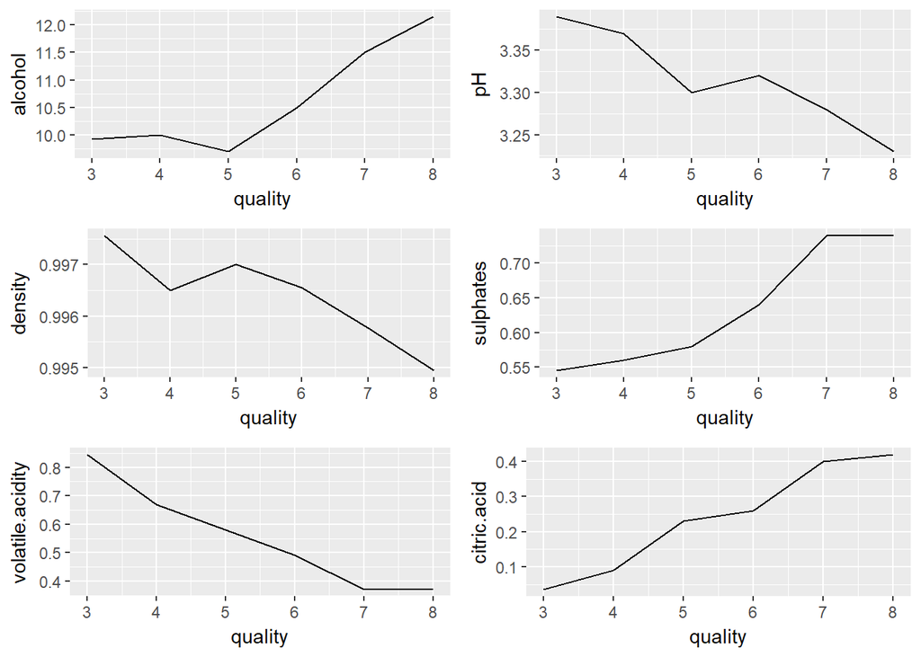

The above plots shows the median variation by quality for different variables for high quality wine (7 and 8) :

- Alcohol has a median between above 11.5 g/dm^3
- pH has median between 3.1 and 3.3
- density is belonw 0.996 g/cm^3
- Sulphates above 0.7 g/dm^3
- Volatile acidity below 0.5 g/dm^3
- Citric around 0.4 g/dm^3

##### Let’s try to look at the correlation between variables with quality rank:

We can check alcohol and density by quality bucket:

Plot1 quality ddivided into 2 groups low and high Plot2 quality divided into 3 groups low medium and high

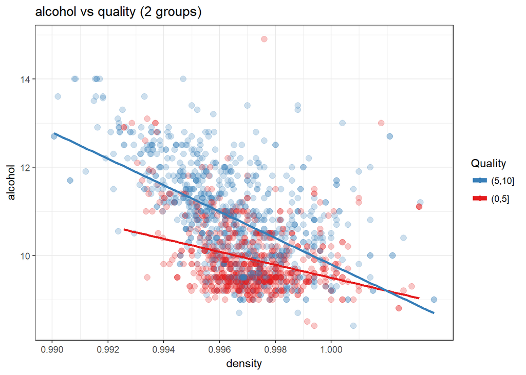

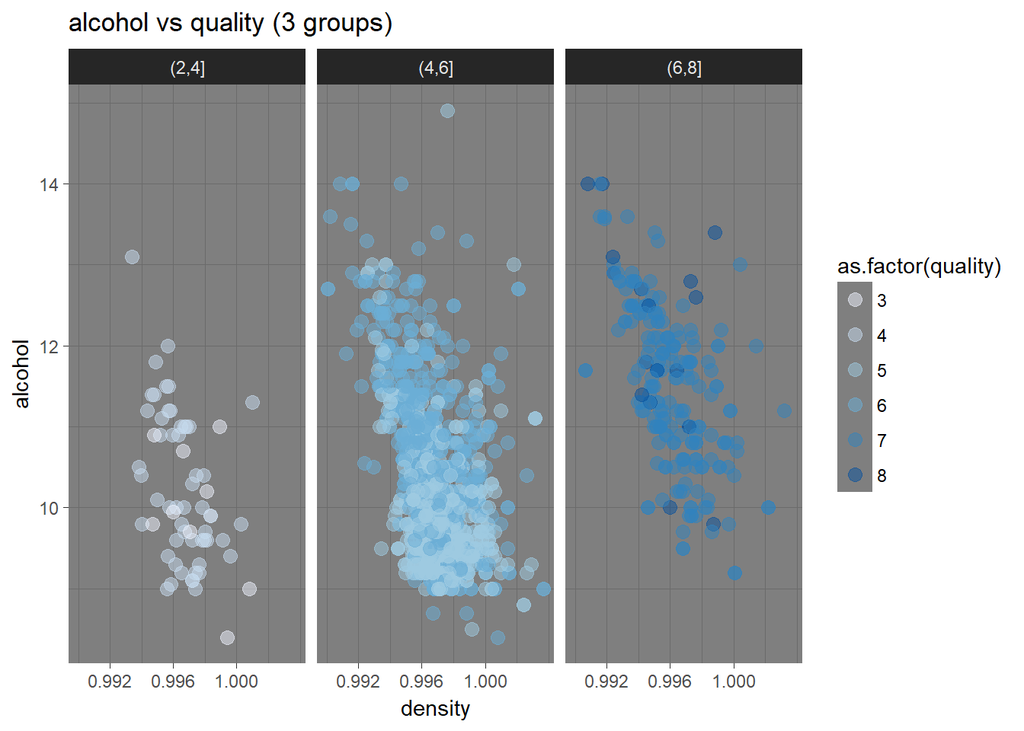

We notice that the Higher quality wine tend to have high alcohol percentage between 11.5 and 12.3 g/dm^3.

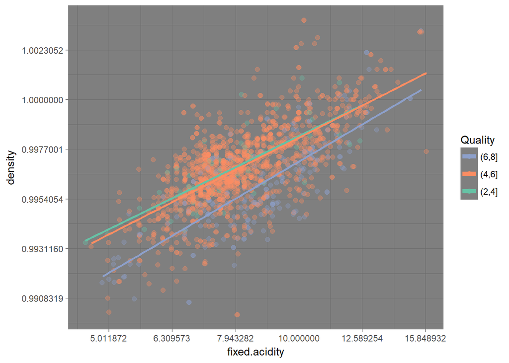

Applying log transformation for x and y axes, the above graph shows the relationship between fixed.acidity and density which looks clear for different quality ranks. Holding fixed.acidity constant it appears that higher quality wines tend to have lower density with most of the observations below 0.997 g/cm^3.

Based in the above the average fixed acidity for High quality wines is around 9 g/dm^3

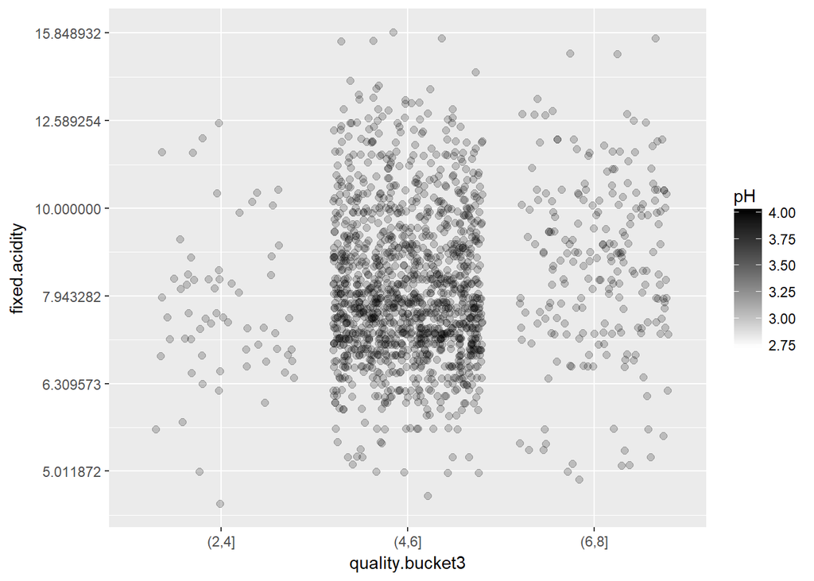

Again transforming y-axis with log10, there is nothing much here from this graph, it seems that pH levels are evenly distributed across the quality levels. But it looks like the Ph level for higher quality wines ranges between 3 and 3.3

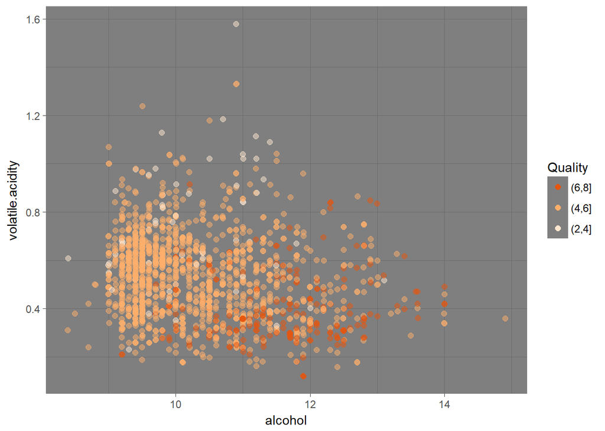

Higher quality wine tend to have lower volatile acidity.

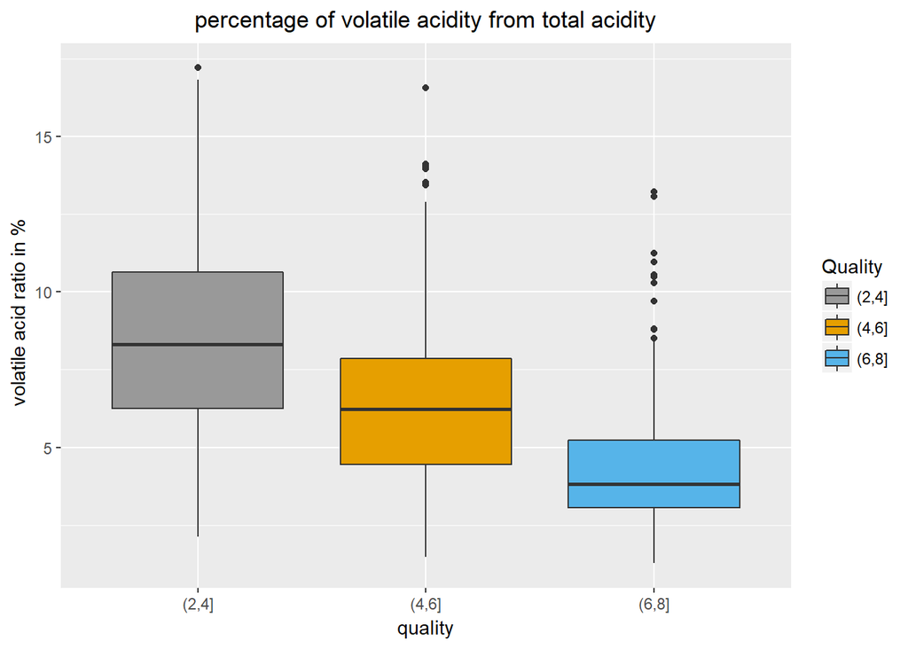

Getting the volatile acidity ratio from total acidity concentration, we notice that the volatile acidity percentage decreases for high quality wine compared to lower quality wine.

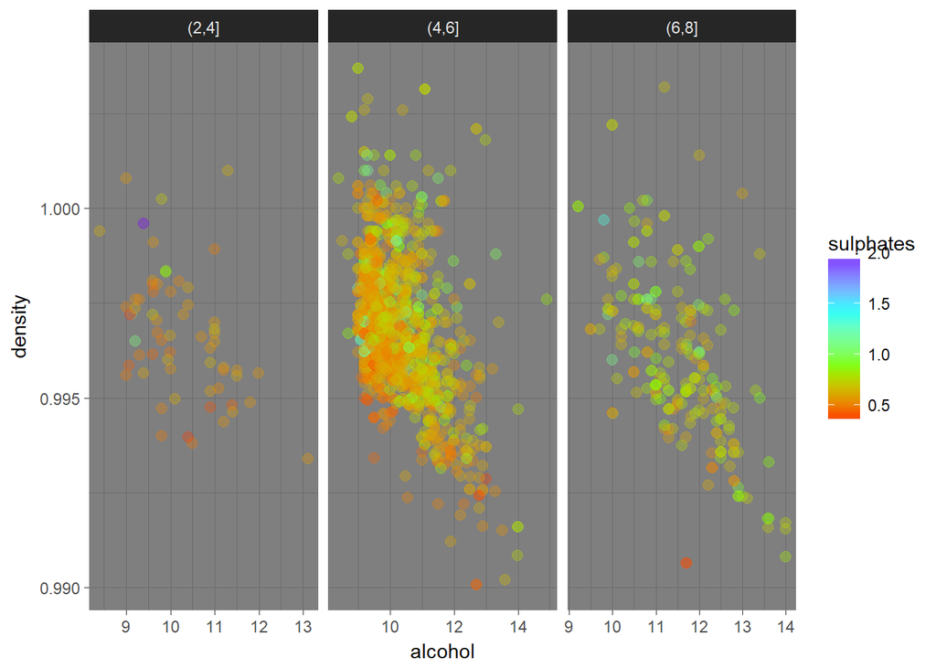

looking at Alcohol vs density and we look at the different sulphates concentration by quality. We notice that higher quality wines from the bucket 6-8 tend to have sulphates levels above 0.5 g/dm^3 holding alcohol and density as constant.

Based on the differents drawn plots we can build linear using the below variables: * alcohol * volatile.acidity * log(sulphates) * fixed.acidity * pH * citric.acidity

```
##
## Calls:
## m1: lm(formula = quality ~ alcohol, data = red_wine)
## m2: lm(formula = quality ~ alcohol + volatile.acidity, data = red_wine)
## m3: lm(formula = quality ~ alcohol + volatile.acidity + log(sulphates),
##     data = red_wine)
## m4: lm(formula = quality ~ alcohol + volatile.acidity + log(sulphates) +
##     pH, data = red_wine)
## m5: lm(formula = quality ~ alcohol + volatile.acidity + log(sulphates) +
##     pH + citric.acid, data = red_wine)
## m6: lm(formula = quality ~ alcohol + volatile.acidity + log(sulphates) +
##     pH + citric.acid + fixed.acidity, data = red_wine)
##
## ========================================================================================================
##                          m1            m2            m3            m4            m5            m6
## --------------------------------------------------------------------------------------------------------
##   (Intercept)           1.875***      3.095***      3.369***      4.240***      5.037***      4.151***
##                        (0.175)       (0.184)       (0.184)       (0.362)       (0.449)       (0.564)
##   alcohol               0.361***      0.314***      0.303***      0.316***      0.323***      0.323***
##                        (0.017)       (0.016)       (0.016)       (0.016)       (0.016)       (0.016)
##   volatile.acidity                   -1.384***     -1.156***     -1.086***     -1.235***     -1.282***
##                                      (0.095)       (0.097)       (0.100)       (0.112)       (0.113)
##   log(sulphates)                                    0.641***      0.616***      0.657***      0.655***
##                                                    (0.077)       (0.077)       (0.078)       (0.078)
##   pH                                                             -0.317**      -0.521***     -0.330*
##                                                                  (0.114)       (0.132)       (0.151)
##   citric.acid                                                                  -0.357**      -0.529***
##                                                                                (0.120)       (0.137)
##   fixed.acidity                                                                               0.039**
##                                                                                              (0.015)
## --------------------------------------------------------------------------------------------------------
##   R-squared             0.227         0.317         0.345         0.349         0.352         0.355
##   adj. R-squared        0.226         0.316         0.344         0.347         0.350         0.353
##   sigma                 0.710         0.668         0.654         0.653         0.651         0.650
##   F                   468.267       370.379       280.646       213.327       173.273       146.036
##   p                     0.000         0.000         0.000         0.000         0.000         0.000
##   Log-likelihood    -1721.057     -1621.814     -1587.752     -1583.855     -1579.425     -1576.050
##   Deviance            805.870       711.796       682.108       678.792       675.040       672.197
##   AIC                3448.114      3251.628      3185.503      3179.711      3172.850      3168.100
##   BIC                3464.245      3273.136      3212.389      3211.974      3210.490      3211.117
##   N                  1599          1599          1599          1599          1599          1599
## ========================================================================================================
```

Looking at the different combination of independent variables, the best mutiple linear model that could explain around 35% (R-squared) of the variance in wine in wine qualiy is the below:

```
##
## Call:
## lm(formula = quality ~ alcohol + volatile.acidity + log(sulphates) +
##     pH + citric.acid + fixed.acidity, data = red_wine)
##
## Residuals:
##      Min       1Q   Median       3Q      Max
## -2.75110 -0.37743 -0.05271  0.45264  2.05472
##
## Coefficients:
##                  Estimate Std. Error t value Pr(>|t|)
## (Intercept)       4.15086    0.56366   7.364 2.85e-13 ***
## alcohol           0.32305    0.01642  19.672  < 2e-16 ***
## volatile.acidity -1.28210    0.11311 -11.335  < 2e-16 ***
## log(sulphates)    0.65451    0.07821   8.369  < 2e-16 ***
## pH               -0.32966    0.15140  -2.177 0.029600 *
## citric.acid      -0.52922    0.13689  -3.866 0.000115 ***
## fixed.acidity     0.03860    0.01487   2.595 0.009544 **
## ---
## Signif. codes:  0 '***' 0.001 '**' 0.01 '*' 0.05 '.' 0.1 ' ' 1
##
## Residual standard error: 0.6498 on 1592 degrees of freedom
## Multiple R-squared:  0.355,  Adjusted R-squared:  0.3526
## F-statistic:   146 on 6 and 1592 DF,  p-value: < 2.2e-16
```

plotting the residuals of the linear regression model below, the distribution looks symmetrical but we have some outliers points especially at the lower ends which suggest that the model may requires further improvements.

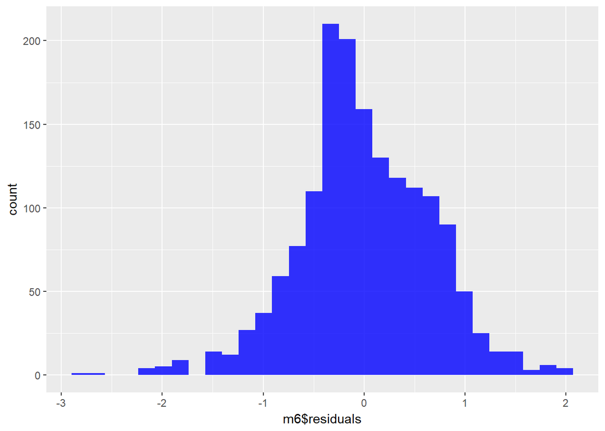

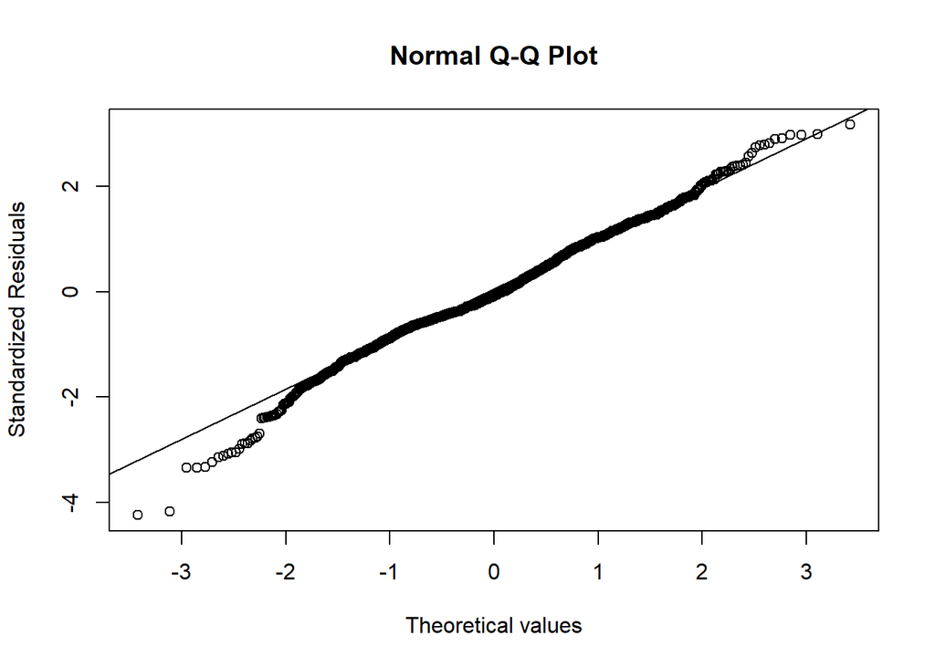

```
##    Min. 1st Qu.  Median    Mean 3rd Qu.    Max.
##   4.334   5.252   5.542   5.612   5.973   7.046
```

it does not seem that the model is accurately predicting low and high quality values.

# Multivariate Analysis

### Talk about some of the relationships you observed in this part of the investigation. Were there features that strengthened each other in terms of looking at your feature(s) of interest?

It is clear that alcohol percentage does impact the Wine Quality. high alcohol level of over 10% contributes to better wine quality. Density is correlated with Alcohol level which makes sense. As a result Higher quality wines tend to have lower density under 0.997. Also it was noticed :

- High quality wine tend to have pH level below 3.4 and higher than 3
- Lower volatile acidity tend to have higher quality
- higher sulphates of over 0.5 g/dm^3 could be an indication of higher quality

### Were there any interesting or surprising interactions between features?

Some of the interesting interaction is between sulphates and Quality and pH and quality

### OPTIONAL: Did you create any models with your dataset? Discuss the strengths and limitations of your model.

The model have the quality as dependant variables and having the following independant variables:

The critical independant variables:

- Alcohol
- volatile.acidity
- log(sulphates)

Adding also other factors to the model appears to improve R-squared, though not that much:

- pH
- citric.acid
- Fixed.acidity

Most important predictor variable in the model is clearly Alcohol. By adding each factor the R-squared improved, though finally the model could explain up to 35% of variability in quality.

plotting the residuals the distribution is approximately symmetric, though with the normality plot we still have some outliers.

It is clear that the model has limitation in that regard, and maybe we should look at different model to better predict the quality of wine.

# Final Plots and Summary

### Plot One

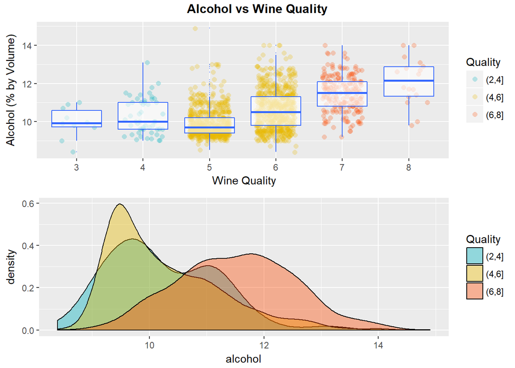

### Description One

The Above plot summarizes the relationship between Alcohol percentage and quality, The boxplot shows that median alcohol percentage tend to increase with quality Also we could depict that most of the observations of wine samples are stacked between quality level 5 and 6. This where density plot also shows the Alcohol distribution by quality buckets.

### Plot Two

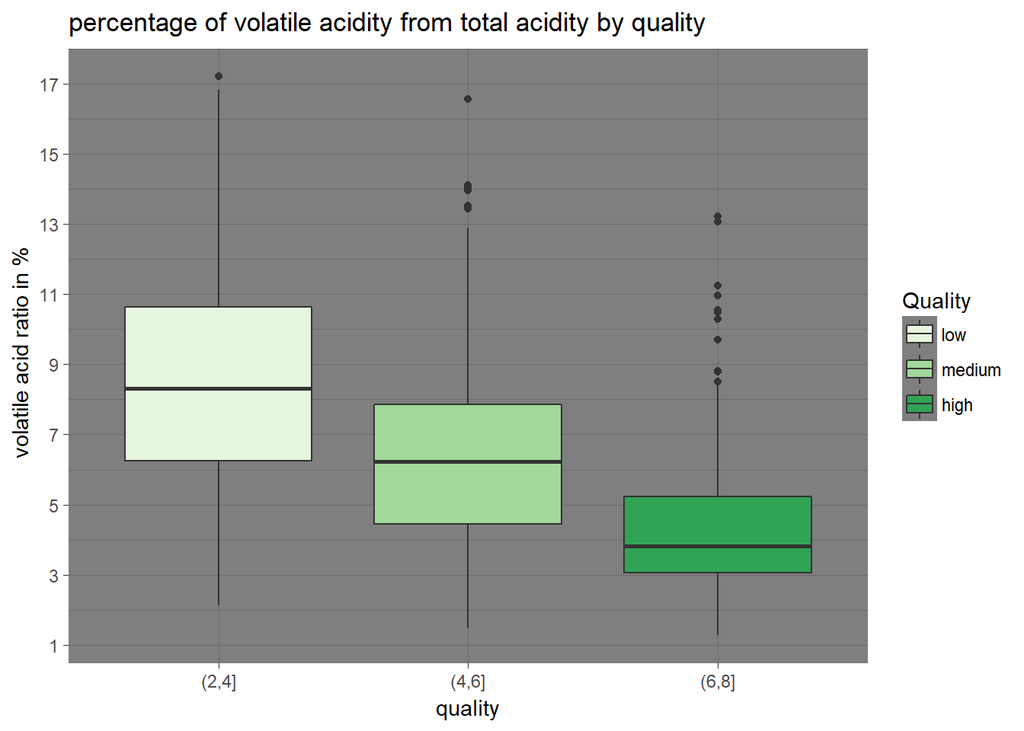

### Description Two

The boxplot shows how the acidity composition of and the percentage of volatile acid available would affect the wine quality.

### Plot Three

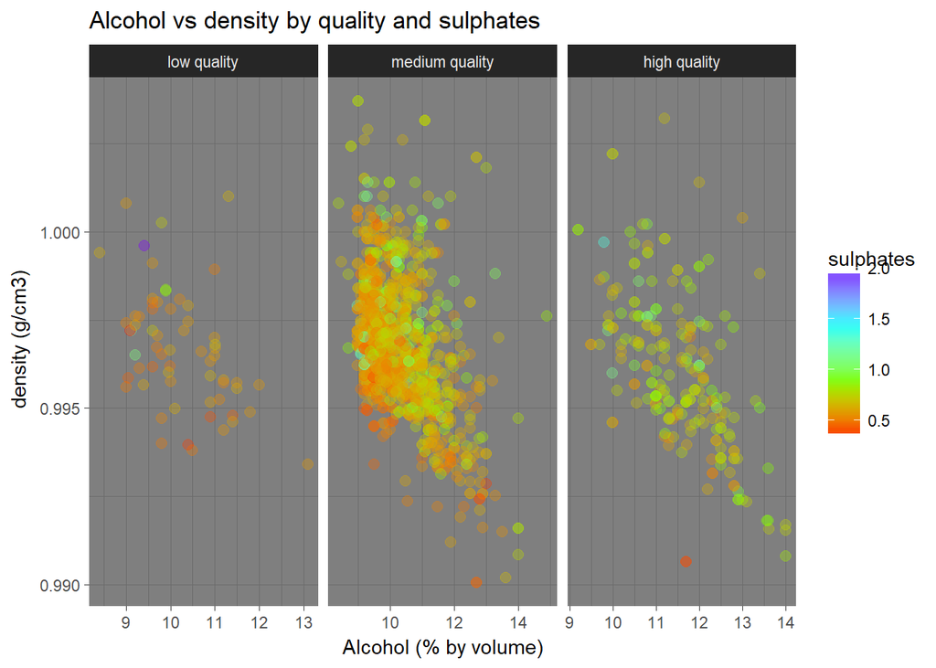

### Description Three

The above plot indicates how higher sulphates may contribute to higher wine quality levels. High quality wine tends to have most observations above 0.5g/dm^3 of sulphates.

# Reflection

This dataset contained 1,599 observations of red wine samples. With 11 physicochemical attributes measured as well as output variable which graded the wine quality based on sensory data from 0 to 10. First I started to understand the indivdual attributes and trying to gather more details about the wine chemical compostions by searching on the internet and drawing plots. The main idea was to understand which chemical properties have the stronger effect on the wine quality. Eventually I have explored wine quality across many variables and created a linear model to estimate the wine quality, though the linear model seems to only account to approximately 35% of the variability in wine quality.

Checking different variables, only few of them had an association with the wine quality. Notably the stronger relationship found was between Alcohol and quality, otherimportant variables like volatile acidity and sulphates appeared also as having a contrbution on the overall wine quality.

Studying the relationship between the different chemical properties, I struggled to find a clear association between the chemical attributes and quality, especially that a lot of these distributions are not normally distributed and contains a lot of outliers. What was suprising that I could not find a clear relationship between pH and quality, though usually pH levels affect the density and taste of the wine and thought this would help explain the wine quality, the same for residual sugar.

On the other hand it was nice to find that lower volatile acid contribute to higher wine quality, since more acetic acid would lead to a sour taste in wine like vinegar.

For the future it would be good to test different model other than the linear model as it might come up with better results with the current data set that we have. This data set is taken from one year, also it would be good to have different wine observations gathered over the years in order draw a better conclusion.

# Reference:

http://www.sthda.com/english/wiki/scatter-plot-matrices-r-base-graphs

http://www.calwineries.com/learn/wine-chemistry/acidity

https://rdrr.io/cran/dplyr/man/summarise_all.html

http://www.r-tutor.com/elementary-statistics/simple-linear-regression/normal-probability-plot-residuals

https://stackoverflow.com/questions/40675778/center-plot-title-in-ggplot2?utm_medium=organic&utm_source=google_rich_qa&utm_campaign=google_rich_qa

http://www.sthda.com/english/wiki/ggplot2-box-plot-quick-start-guide-r-software-and-data-visualization

https://stackoverflow.com/questions/14726078/changing-title-in-multiplot-ggplot2-using-grid-arrange?utm_medium=organic&utm_source=google_rich_qa&utm_campaign=google_rich_qa

http://web.uvic.ca/~afyshe/dm_projs/wine_final_report.pdf

https://research.wsulibs.wsu.edu/xmlui/bitstream/handle/2376/4103/Villamor_wsu_0251E_10425.pdf

https://ac.els-cdn.com/S221418121400024X/1-s2.0-S221418121400024X-main.pdf?_tid=1058193f-84bc-4de3-978d-c4a9ac4f53ed&acdnat=1523116936_65486008c13756553d485c26056a00c0

https://stackoverflow.com/questions/8317231/elegant-way-to-report-missing-values-in-a-data-frame?utm_medium=organic&utm_source=google_rich_qa&utm_campaign=google_rich_qa

https://www.statmethods.net/input/missingdata.html

https://grapesandwine.cals.cornell.edu/sites/grapesandwine.cals.cornell.edu/files/shared/Research%20Focus%202015-4.pdf

https://www.morebeer.com/web_files/morebeer.com/files/Manuals/so2.pdf

http://www.gencowinemakers.com/docs/Acids%20Presentation.pdf

https://stackoverflow.com/questions/26075181/multiple-groups-in-geom-density-plot?utm_medium=organic&utm_source=google_rich_qa&utm_campaign=google_rich_qa